# Risk Factor Analysis

## Outcome Variable

**Outcome Variable:** ever_wasted

## Predictor Variables

**Intervention Variable:** month

**Adjustment Set:**

unadjusted

## Stratifying Variables

The analysis was stratified on these variable(s):

- agecat
- studyid
- country

## Data Summary

| agecat | studyid | country | month | ever_wasted | n_cell | n |
| --- | --- | --- | --- | --- | --- | --- |
| 0-24 months (no birth wast) | CMC-V-BCS-2002 | INDIA | 1 | 0 | 13 | 368 |
| 0-24 months (no birth wast) | CMC-V-BCS-2002 | INDIA | 1 | 1 | 15 | 368 |
| 0-24 months (no birth wast) | CMC-V-BCS-2002 | INDIA | 2 | 0 | 13 | 368 |
| 0-24 months (no birth wast) | CMC-V-BCS-2002 | INDIA | 2 | 1 | 10 | 368 |
| 0-24 months (no birth wast) | CMC-V-BCS-2002 | INDIA | 3 | 0 | 13 | 368 |
| 0-24 months (no birth wast) | CMC-V-BCS-2002 | INDIA | 3 | 1 | 11 | 368 |
| 0-24 months (no birth wast) | CMC-V-BCS-2002 | INDIA | 4 | 0 | 21 | 368 |
| 0-24 months (no birth wast) | CMC-V-BCS-2002 | INDIA | 4 | 1 | 8 | 368 |
| 0-24 months (no birth wast) | CMC-V-BCS-2002 | INDIA | 5 | 0 | 27 | 368 |
| 0-24 months (no birth wast) | CMC-V-BCS-2002 | INDIA | 5 | 1 | 16 | 368 |
| 0-24 months (no birth wast) | CMC-V-BCS-2002 | INDIA | 6 | 0 | 21 | 368 |
| 0-24 months (no birth wast) | CMC-V-BCS-2002 | INDIA | 6 | 1 | 14 | 368 |
| 0-24 months (no birth wast) | CMC-V-BCS-2002 | INDIA | 7 | 0 | 20 | 368 |
| 0-24 months (no birth wast) | CMC-V-BCS-2002 | INDIA | 7 | 1 | 13 | 368 |
| 0-24 months (no birth wast) | CMC-V-BCS-2002 | INDIA | 8 | 0 | 22 | 368 |
| 0-24 months (no birth wast) | CMC-V-BCS-2002 | INDIA | 8 | 1 | 19 | 368 |
| 0-24 months (no birth wast) | CMC-V-BCS-2002 | INDIA | 9 | 0 | 9 | 368 |
| 0-24 months (no birth wast) | CMC-V-BCS-2002 | INDIA | 9 | 1 | 14 | 368 |
| 0-24 months (no birth wast) | CMC-V-BCS-2002 | INDIA | 10 | 0 | 12 | 368 |
| 0-24 months (no birth wast) | CMC-V-BCS-2002 | INDIA | 10 | 1 | 7 | 368 |
| 0-24 months (no birth wast) | CMC-V-BCS-2002 | INDIA | 11 | 0 | 20 | 368 |
| 0-24 months (no birth wast) | CMC-V-BCS-2002 | INDIA | 11 | 1 | 21 | 368 |
| 0-24 months (no birth wast) | CMC-V-BCS-2002 | INDIA | 12 | 0 | 11 | 368 |
| 0-24 months (no birth wast) | CMC-V-BCS-2002 | INDIA | 12 | 1 | 18 | 368 |
| 0-24 months (no birth wast) | CMIN | BANGLADESH | 1 | 0 | 15 | 268 |
| 0-24 months (no birth wast) | CMIN | BANGLADESH | 1 | 1 | 13 | 268 |
| 0-24 months (no birth wast) | CMIN | BANGLADESH | 2 | 0 | 19 | 268 |
| 0-24 months (no birth wast) | CMIN | BANGLADESH | 2 | 1 | 15 | 268 |
| 0-24 months (no birth wast) | CMIN | BANGLADESH | 3 | 0 | 13 | 268 |
| 0-24 months (no birth wast) | CMIN | BANGLADESH | 3 | 1 | 7 | 268 |

[output cut: 1194 more lines]

The following strata were considered:

- agecat: 0-24 months (no birth wast), studyid: CMC-V-BCS-2002, country: INDIA
- agecat: 0-24 months (no birth wast), studyid: CMIN, country: BANGLADESH
- agecat: 0-24 months (no birth wast), studyid: CONTENT, country: PERU
- agecat: 0-24 months (no birth wast), studyid: EE, country: PAKISTAN
- agecat: 0-24 months (no birth wast), studyid: GMS-Nepal, country: NEPAL
- agecat: 0-24 months (no birth wast), studyid: Guatemala BSC, country: GUATEMALA
- agecat: 0-24 months (no birth wast), studyid: iLiNS-Zinc, country: BURKINA FASO
- agecat: 0-24 months (no birth wast), studyid: IRC, country: INDIA
- agecat: 0-24 months (no birth wast), studyid: JiVitA-3, country: BANGLADESH
- agecat: 0-24 months (no birth wast), studyid: JiVitA-4, country: BANGLADESH
- agecat: 0-24 months (no birth wast), studyid: Keneba, country: GAMBIA
- agecat: 0-24 months (no birth wast), studyid: LCNI-5, country: MALAWI
- agecat: 0-24 months (no birth wast), studyid: MAL-ED, country: BANGLADESH
- agecat: 0-24 months (no birth wast), studyid: MAL-ED, country: BRAZIL
- agecat: 0-24 months (no birth wast), studyid: MAL-ED, country: INDIA
- agecat: 0-24 months (no birth wast), studyid: MAL-ED, country: NEPAL
- agecat: 0-24 months (no birth wast), studyid: MAL-ED, country: PERU
- agecat: 0-24 months (no birth wast), studyid: MAL-ED, country: SOUTH AFRICA
- agecat: 0-24 months (no birth wast), studyid: MAL-ED, country: TANZANIA, UNITED REPUBLIC OF
- agecat: 0-24 months (no birth wast), studyid: NIH-Birth, country: BANGLADESH
- agecat: 0-24 months (no birth wast), studyid: PROBIT, country: BELARUS
- agecat: 0-24 months (no birth wast), studyid: ResPak, country: PAKISTAN
- agecat: 0-24 months (no birth wast), studyid: SAS-CompFeed, country: INDIA
- agecat: 0-24 months (no birth wast), studyid: SAS-FoodSuppl, country: INDIA
- agecat: 0-24 months (no birth wast), studyid: TanzaniaChild2, country: TANZANIA, UNITED REPUBLIC OF
- agecat: 0-24 months (no birth wast), studyid: ZVITAMBO, country: ZIMBABWE
- agecat: 0-6 months (no birth wast), studyid: CMC-V-BCS-2002, country: INDIA
- agecat: 0-6 months (no birth wast), studyid: CMIN, country: BANGLADESH
- agecat: 0-6 months (no birth wast), studyid: CONTENT, country: PERU
- agecat: 0-6 months (no birth wast), studyid: EE, country: PAKISTAN
- agecat: 0-6 months (no birth wast), studyid: GMS-Nepal, country: NEPAL
- agecat: 0-6 months (no birth wast), studyid: Guatemala BSC, country: GUATEMALA
- agecat: 0-6 months (no birth wast), studyid: IRC, country: INDIA
- agecat: 0-6 months (no birth wast), studyid: JiVitA-3, country: BANGLADESH
- agecat: 0-6 months (no birth wast), studyid: JiVitA-4, country: BANGLADESH
- agecat: 0-6 months (no birth wast), studyid: Keneba, country: GAMBIA
- agecat: 0-6 months (no birth wast), studyid: LCNI-5, country: MALAWI
- agecat: 0-6 months (no birth wast), studyid: MAL-ED, country: BANGLADESH
- agecat: 0-6 months (no birth wast), studyid: MAL-ED, country: BRAZIL
- agecat: 0-6 months (no birth wast), studyid: MAL-ED, country: INDIA
- agecat: 0-6 months (no birth wast), studyid: MAL-ED, country: NEPAL
- agecat: 0-6 months (no birth wast), studyid: MAL-ED, country: PERU
- agecat: 0-6 months (no birth wast), studyid: MAL-ED, country: SOUTH AFRICA
- agecat: 0-6 months (no birth wast), studyid: MAL-ED, country: TANZANIA, UNITED REPUBLIC OF
- agecat: 0-6 months (no birth wast), studyid: NIH-Birth, country: BANGLADESH
- agecat: 0-6 months (no birth wast), studyid: PROBIT, country: BELARUS
- agecat: 0-6 months (no birth wast), studyid: ResPak, country: PAKISTAN
- agecat: 0-6 months (no birth wast), studyid: SAS-CompFeed, country: INDIA
- agecat: 0-6 months (no birth wast), studyid: SAS-FoodSuppl, country: INDIA
- agecat: 0-6 months (no birth wast), studyid: TanzaniaChild2, country: TANZANIA, UNITED REPUBLIC OF
- agecat: 0-6 months (no birth wast), studyid: ZVITAMBO, country: ZIMBABWE

### Dropped Strata

Some strata were dropped due to rare outcomes:

- agecat: 0-24 months (no birth wast), studyid: CMIN, country: BANGLADESH
- agecat: 0-24 months (no birth wast), studyid: CONTENT, country: PERU
- agecat: 0-24 months (no birth wast), studyid: EE, country: PAKISTAN
- agecat: 0-24 months (no birth wast), studyid: GMS-Nepal, country: NEPAL
- agecat: 0-24 months (no birth wast), studyid: Guatemala BSC, country: GUATEMALA
- agecat: 0-24 months (no birth wast), studyid: LCNI-5, country: MALAWI
- agecat: 0-24 months (no birth wast), studyid: MAL-ED, country: BANGLADESH
- agecat: 0-24 months (no birth wast), studyid: MAL-ED, country: BRAZIL
- agecat: 0-24 months (no birth wast), studyid: MAL-ED, country: INDIA
- agecat: 0-24 months (no birth wast), studyid: MAL-ED, country: NEPAL
- agecat: 0-24 months (no birth wast), studyid: MAL-ED, country: PERU
- agecat: 0-24 months (no birth wast), studyid: MAL-ED, country: SOUTH AFRICA
- agecat: 0-24 months (no birth wast), studyid: MAL-ED, country: TANZANIA, UNITED REPUBLIC OF
- agecat: 0-24 months (no birth wast), studyid: ResPak, country: PAKISTAN
- agecat: 0-24 months (no birth wast), studyid: SAS-FoodSuppl, country: INDIA
- agecat: 0-6 months (no birth wast), studyid: CMIN, country: BANGLADESH
- agecat: 0-6 months (no birth wast), studyid: CONTENT, country: PERU
- agecat: 0-6 months (no birth wast), studyid: EE, country: PAKISTAN
- agecat: 0-6 months (no birth wast), studyid: GMS-Nepal, country: NEPAL
- agecat: 0-6 months (no birth wast), studyid: Guatemala BSC, country: GUATEMALA
- agecat: 0-6 months (no birth wast), studyid: IRC, country: INDIA
- agecat: 0-6 months (no birth wast), studyid: JiVitA-4, country: BANGLADESH
- agecat: 0-6 months (no birth wast), studyid: LCNI-5, country: MALAWI
- agecat: 0-6 months (no birth wast), studyid: MAL-ED, country: BANGLADESH
- agecat: 0-6 months (no birth wast), studyid: MAL-ED, country: BRAZIL
- agecat: 0-6 months (no birth wast), studyid: MAL-ED, country: INDIA
- agecat: 0-6 months (no birth wast), studyid: MAL-ED, country: NEPAL
- agecat: 0-6 months (no birth wast), studyid: MAL-ED, country: PERU
- agecat: 0-6 months (no birth wast), studyid: MAL-ED, country: SOUTH AFRICA
- agecat: 0-6 months (no birth wast), studyid: MAL-ED, country: TANZANIA, UNITED REPUBLIC OF
- agecat: 0-6 months (no birth wast), studyid: NIH-Birth, country: BANGLADESH
- agecat: 0-6 months (no birth wast), studyid: ResPak, country: PAKISTAN
- agecat: 0-6 months (no birth wast), studyid: SAS-FoodSuppl, country: INDIA

## Methods Detail

We're interested in the causal parameters $E[Y_a]$ for all values of $a \in \mathcal{A}$. These parameters represent the mean outcome if, possibly contrary to fact, we intervened to set all units to have $A=a$. Under the randomization and positivity assumptions, these are identified by the statistical parameters $\psi_a=E_W[E_{Y|A,W}(Y|A=a,W)]$. In addition, we're interested in the mean of $Y$, $E[Y]$ under no intervention (the observed mean). We will estimate these parameters by using SuperLearner to fit the relevant likelihood factors -- $E_{Y|A,W}(Y|A=a,W)$ and $p(A=a|W)$, and then updating our likelihood fit using a joint TMLE.

For unadjusted analyses ($W=\{\}$), initial likelihoods were estimated using Lrnr_glm to estimate the simple $E(Y|A)$ and Lrnr_mean to estimate $p(A)$. For adjusted analyses, a small library containing Lrnr_glmnet, Lrnr_xgboost, and Lrnr_mean was used.

Having estimated these parameters, we will then use the delta method to estimate relative risks and attributable risks relative to a prespecified baseline level of $A$.

# Results Detail

## Results Plots

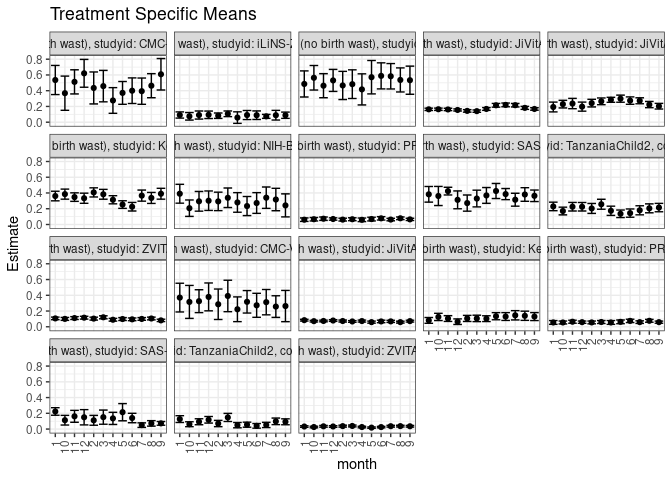

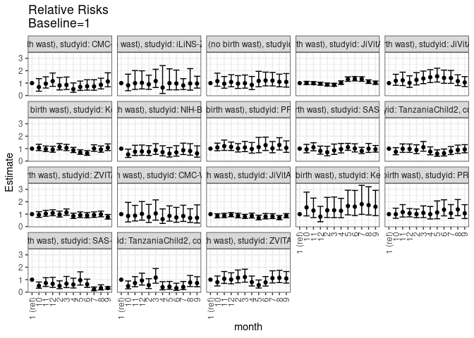

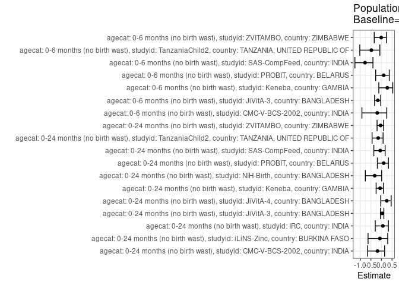

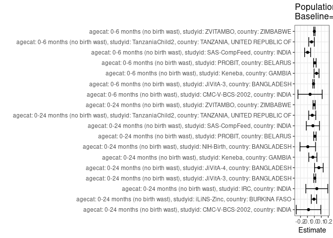

## Results Table

### Parameter: TSM

| agecat | studyid | country | intervention_level | baseline_level | estimate | ci_lower | ci_upper |
| --- | --- | --- | --- | --- | --- | --- | --- |
| 0-24 months (no birth wast) | CMC-V-BCS-2002 | INDIA | 1 | NA | 0.5357143 | 0.3507366 | 0.7206919 |
| 0-24 months (no birth wast) | CMC-V-BCS-2002 | INDIA | 2 | NA | 0.4347826 | 0.2319121 | 0.6376531 |
| 0-24 months (no birth wast) | CMC-V-BCS-2002 | INDIA | 3 | NA | 0.4583333 | 0.2587197 | 0.6579469 |
| 0-24 months (no birth wast) | CMC-V-BCS-2002 | INDIA | 4 | NA | 0.2758621 | 0.1129712 | 0.4387529 |
| 0-24 months (no birth wast) | CMC-V-BCS-2002 | INDIA | 5 | NA | 0.3720930 | 0.2274231 | 0.5167629 |
| 0-24 months (no birth wast) | CMC-V-BCS-2002 | INDIA | 6 | NA | 0.4000000 | 0.2374786 | 0.5625214 |
| 0-24 months (no birth wast) | CMC-V-BCS-2002 | INDIA | 7 | NA | 0.3939394 | 0.2270016 | 0.5608772 |
| 0-24 months (no birth wast) | CMC-V-BCS-2002 | INDIA | 8 | NA | 0.4634146 | 0.3105696 | 0.6162597 |
| 0-24 months (no birth wast) | CMC-V-BCS-2002 | INDIA | 9 | NA | 0.6086957 | 0.4089706 | 0.8084207 |
| 0-24 months (no birth wast) | CMC-V-BCS-2002 | INDIA | 10 | NA | 0.3684211 | 0.1512269 | 0.5856152 |
| 0-24 months (no birth wast) | CMC-V-BCS-2002 | INDIA | 11 | NA | 0.5121951 | 0.3589849 | 0.6654054 |
| 0-24 months (no birth wast) | CMC-V-BCS-2002 | INDIA | 12 | NA | 0.6206897 | 0.4438521 | 0.7975272 |
| 0-24 months (no birth wast) | iLiNS-Zinc | BURKINA FASO | 1 | NA | 0.0913043 | 0.0521520 | 0.1304567 |
| 0-24 months (no birth wast) | iLiNS-Zinc | BURKINA FASO | 2 | NA | 0.0824742 | 0.0482164 | 0.1167321 |
| 0-24 months (no birth wast) | iLiNS-Zinc | BURKINA FASO | 3 | NA | 0.1067961 | 0.0708294 | 0.1427628 |
| 0-24 months (no birth wast) | iLiNS-Zinc | BURKINA FASO | 4 | NA | 0.0584795 | -0.0147508 | 0.1317099 |
| 0-24 months (no birth wast) | iLiNS-Zinc | BURKINA FASO | 5 | NA | 0.0909091 | 0.0333445 | 0.1484737 |
| 0-24 months (no birth wast) | iLiNS-Zinc | BURKINA FASO | 6 | NA | 0.0888252 | 0.0345812 | 0.1430692 |
| 0-24 months (no birth wast) | iLiNS-Zinc | BURKINA FASO | 7 | NA | 0.0739796 | 0.0489020 | 0.0990572 |
| 0-24 months (no birth wast) | iLiNS-Zinc | BURKINA FASO | 8 | NA | 0.0887574 | 0.0275400 | 0.1499748 |
| 0-24 months (no birth wast) | iLiNS-Zinc | BURKINA FASO | 9 | NA | 0.0882353 | 0.0483938 | 0.1280768 |
| 0-24 months (no birth wast) | iLiNS-Zinc | BURKINA FASO | 10 | NA | 0.0747922 | 0.0269183 | 0.1226662 |
| 0-24 months (no birth wast) | iLiNS-Zinc | BURKINA FASO | 11 | NA | 0.0909091 | 0.0397598 | 0.1420584 |
| 0-24 months (no birth wast) | iLiNS-Zinc | BURKINA FASO | 12 | NA | 0.0939597 | 0.0465824 | 0.1413370 |
| 0-24 months (no birth wast) | IRC | INDIA | 1 | NA | 0.4857143 | 0.3199319 | 0.6514966 |
| 0-24 months (no birth wast) | IRC | INDIA | 2 | NA | 0.4666667 | 0.2879267 | 0.6454067 |
| 0-24 months (no birth wast) | IRC | INDIA | 3 | NA | 0.4827586 | 0.3006660 | 0.6648512 |
| 0-24 months (no birth wast) | IRC | INDIA | 4 | NA | 0.4166667 | 0.2191850 | 0.6141483 |
| 0-24 months (no birth wast) | IRC | INDIA | 5 | NA | 0.5714286 | 0.3595131 | 0.7833440 |
| 0-24 months (no birth wast) | IRC | INDIA | 6 | NA | 0.5882353 | 0.4226048 | 0.7538658 |

[output cut: 186 more lines]

### Parameter: E(Y)

| agecat | studyid | country | intervention_level | baseline_level | estimate | ci_lower | ci_upper |
| --- | --- | --- | --- | --- | --- | --- | --- |
| 0-24 months (no birth wast) | CMC-V-BCS-2002 | INDIA | NA | NA | 0.4510870 | 0.4001777 | 0.5019962 |
| 0-24 months (no birth wast) | iLiNS-Zinc | BURKINA FASO | NA | NA | 0.0850857 | 0.0676201 | 0.1025513 |
| 0-24 months (no birth wast) | IRC | INDIA | NA | NA | 0.5207824 | 0.4723080 | 0.5692568 |
| 0-24 months (no birth wast) | JiVitA-3 | BANGLADESH | NA | NA | 0.1693995 | 0.1641138 | 0.1746853 |
| 0-24 months (no birth wast) | JiVitA-4 | BANGLADESH | NA | NA | 0.2577835 | 0.2441424 | 0.2714247 |
| 0-24 months (no birth wast) | Keneba | GAMBIA | NA | NA | 0.3392608 | 0.3219301 | 0.3565915 |
| 0-24 months (no birth wast) | NIH-Birth | BANGLADESH | NA | NA | 0.2956811 | 0.2591967 | 0.3321655 |
| 0-24 months (no birth wast) | PROBIT | BELARUS | NA | NA | 0.0680135 | 0.0562135 | 0.0798135 |
| 0-24 months (no birth wast) | SAS-CompFeed | INDIA | NA | NA | 0.3615180 | 0.3107193 | 0.4123167 |
| 0-24 months (no birth wast) | TanzaniaChild2 | TANZANIA, UNITED REPUBLIC OF | NA | NA | 0.1988255 | 0.1828010 | 0.2148500 |
| 0-24 months (no birth wast) | ZVITAMBO | ZIMBABWE | NA | NA | 0.1020019 | 0.0969221 | 0.1070817 |
| 0-6 months (no birth wast) | CMC-V-BCS-2002 | INDIA | NA | NA | 0.3085714 | 0.2601110 | 0.3570318 |
| 0-6 months (no birth wast) | JiVitA-3 | BANGLADESH | NA | NA | 0.0717008 | 0.0680635 | 0.0753382 |
| 0-6 months (no birth wast) | Keneba | GAMBIA | NA | NA | 0.1117987 | 0.0992515 | 0.1243458 |
| 0-6 months (no birth wast) | PROBIT | BELARUS | NA | NA | 0.0612233 | 0.0502388 | 0.0722078 |
| 0-6 months (no birth wast) | SAS-CompFeed | INDIA | NA | NA | 0.1255940 | 0.0954030 | 0.1557851 |
| 0-6 months (no birth wast) | TanzaniaChild2 | TANZANIA, UNITED REPUBLIC OF | NA | NA | 0.0858586 | 0.0745914 | 0.0971258 |
| 0-6 months (no birth wast) | ZVITAMBO | ZIMBABWE | NA | NA | 0.0319976 | 0.0290150 | 0.0349802 |

### Parameter: RR

| agecat | studyid | country | intervention_level | baseline_level | estimate | ci_lower | ci_upper |
| --- | --- | --- | --- | --- | --- | --- | --- |
| 0-24 months (no birth wast) | CMC-V-BCS-2002 | INDIA | 1 | 1 | 1.0000000 | 1.0000000 | 1.0000000 |
| 0-24 months (no birth wast) | CMC-V-BCS-2002 | INDIA | 2 | 1 | 0.8115942 | 0.4541974 | 1.4502179 |
| 0-24 months (no birth wast) | CMC-V-BCS-2002 | INDIA | 3 | 1 | 0.8555556 | 0.4907620 | 1.4915077 |
| 0-24 months (no birth wast) | CMC-V-BCS-2002 | INDIA | 4 | 1 | 0.5149425 | 0.2598304 | 1.0205343 |
| 0-24 months (no birth wast) | CMC-V-BCS-2002 | INDIA | 5 | 1 | 0.6945736 | 0.4129415 | 1.1682831 |
| 0-24 months (no birth wast) | CMC-V-BCS-2002 | INDIA | 6 | 1 | 0.7466667 | 0.4380849 | 1.2726098 |
| 0-24 months (no birth wast) | CMC-V-BCS-2002 | INDIA | 7 | 1 | 0.7353535 | 0.4256947 | 1.2702644 |
| 0-24 months (no birth wast) | CMC-V-BCS-2002 | INDIA | 8 | 1 | 0.8650407 | 0.5366106 | 1.3944847 |
| 0-24 months (no birth wast) | CMC-V-BCS-2002 | INDIA | 9 | 1 | 1.1362319 | 0.7056675 | 1.8295058 |
| 0-24 months (no birth wast) | CMC-V-BCS-2002 | INDIA | 10 | 1 | 0.6877193 | 0.3472956 | 1.3618309 |
| 0-24 months (no birth wast) | CMC-V-BCS-2002 | INDIA | 11 | 1 | 0.9560976 | 0.6054796 | 1.5097495 |
| 0-24 months (no birth wast) | CMC-V-BCS-2002 | INDIA | 12 | 1 | 1.1586207 | 0.7405018 | 1.8128272 |
| 0-24 months (no birth wast) | iLiNS-Zinc | BURKINA FASO | 1 | 1 | 1.0000000 | 1.0000000 | 1.0000000 |
| 0-24 months (no birth wast) | iLiNS-Zinc | BURKINA FASO | 2 | 1 | 0.9032892 | 0.4978203 | 1.6390077 |
| 0-24 months (no birth wast) | iLiNS-Zinc | BURKINA FASO | 3 | 1 | 1.1696718 | 0.6472774 | 2.1136719 |
| 0-24 months (no birth wast) | iLiNS-Zinc | BURKINA FASO | 4 | 1 | 0.6404901 | 0.1702923 | 2.4089620 |
| 0-24 months (no birth wast) | iLiNS-Zinc | BURKINA FASO | 5 | 1 | 0.9956710 | 0.4609213 | 2.1508245 |
| 0-24 months (no birth wast) | iLiNS-Zinc | BURKINA FASO | 6 | 1 | 0.9728476 | 0.4612382 | 2.0519387 |
| 0-24 months (no birth wast) | iLiNS-Zinc | BURKINA FASO | 7 | 1 | 0.8102527 | 0.4836418 | 1.3574290 |
| 0-24 months (no birth wast) | iLiNS-Zinc | BURKINA FASO | 8 | 1 | 0.9721048 | 0.4363746 | 2.1655425 |
| 0-24 months (no birth wast) | iLiNS-Zinc | BURKINA FASO | 9 | 1 | 0.9663866 | 0.6025337 | 1.5499596 |
| 0-24 months (no birth wast) | iLiNS-Zinc | BURKINA FASO | 10 | 1 | 0.8191531 | 0.3900277 | 1.7204212 |
| 0-24 months (no birth wast) | iLiNS-Zinc | BURKINA FASO | 11 | 1 | 0.9956710 | 0.4935339 | 2.0086984 |
| 0-24 months (no birth wast) | iLiNS-Zinc | BURKINA FASO | 12 | 1 | 1.0290828 | 0.5318362 | 1.9912360 |
| 0-24 months (no birth wast) | IRC | INDIA | 1 | 1 | 1.0000000 | 1.0000000 | 1.0000000 |
| 0-24 months (no birth wast) | IRC | INDIA | 2 | 1 | 0.9607843 | 0.5752028 | 1.6048366 |
| 0-24 months (no birth wast) | IRC | INDIA | 3 | 1 | 0.9939148 | 0.5976208 | 1.6529992 |
| 0-24 months (no birth wast) | IRC | INDIA | 4 | 1 | 0.8578431 | 0.4783567 | 1.5383809 |
| 0-24 months (no birth wast) | IRC | INDIA | 5 | 1 | 1.1764706 | 0.7107083 | 1.9474700 |
| 0-24 months (no birth wast) | IRC | INDIA | 6 | 1 | 1.2110727 | 0.7780507 | 1.8850918 |

[output cut: 186 more lines]

### Parameter: PAR

| agecat | studyid | country | intervention_level | baseline_level | estimate | ci_lower | ci_upper |
| --- | --- | --- | --- | --- | --- | --- | --- |
| 0-24 months (no birth wast) | CMC-V-BCS-2002 | INDIA | 1 | NA | -0.0846273 | -0.2623957 | 0.0931410 |
| 0-24 months (no birth wast) | iLiNS-Zinc | BURKINA FASO | 1 | NA | -0.0062186 | -0.0443328 | 0.0318956 |
| 0-24 months (no birth wast) | IRC | INDIA | 1 | NA | 0.0350681 | -0.1234555 | 0.1935917 |
| 0-24 months (no birth wast) | JiVitA-3 | BANGLADESH | 1 | NA | 0.0059075 | -0.0078246 | 0.0196395 |
| 0-24 months (no birth wast) | JiVitA-4 | BANGLADESH | 1 | NA | 0.0648011 | 0.0022516 | 0.1273506 |
| 0-24 months (no birth wast) | Keneba | GAMBIA | 1 | NA | -0.0220837 | -0.0804624 | 0.0362949 |
| 0-24 months (no birth wast) | NIH-Birth | BANGLADESH | 1 | NA | -0.0949439 | -0.2071918 | 0.0173039 |
| 0-24 months (no birth wast) | PROBIT | BELARUS | 1 | NA | 0.0071513 | -0.0101298 | 0.0244324 |
| 0-24 months (no birth wast) | SAS-CompFeed | INDIA | 1 | NA | -0.0216596 | -0.1164395 | 0.0731203 |
| 0-24 months (no birth wast) | TanzaniaChild2 | TANZANIA, UNITED REPUBLIC OF | 1 | NA | -0.0306117 | -0.0818765 | 0.0206531 |
| 0-24 months (no birth wast) | ZVITAMBO | ZIMBABWE | 1 | NA | -0.0041728 | -0.0198850 | 0.0115394 |
| 0-6 months (no birth wast) | CMC-V-BCS-2002 | INDIA | 1 | NA | -0.0617989 | -0.2364075 | 0.1128096 |
| 0-6 months (no birth wast) | JiVitA-3 | BANGLADESH | 1 | NA | -0.0121675 | -0.0225543 | -0.0017807 |
| 0-6 months (no birth wast) | Keneba | GAMBIA | 1 | NA | 0.0308463 | -0.0049733 | 0.0666659 |
| 0-6 months (no birth wast) | PROBIT | BELARUS | 1 | NA | 0.0063348 | -0.0126192 | 0.0252887 |
| 0-6 months (no birth wast) | SAS-CompFeed | INDIA | 1 | NA | -0.0977069 | -0.1409469 | -0.0544670 |
| 0-6 months (no birth wast) | TanzaniaChild2 | TANZANIA, UNITED REPUBLIC OF | 1 | NA | -0.0407790 | -0.0810935 | -0.0004644 |
| 0-6 months (no birth wast) | ZVITAMBO | ZIMBABWE | 1 | NA | -0.0003599 | -0.0095022 | 0.0087824 |

### Parameter: PAF

| agecat | studyid | country | intervention_level | baseline_level | estimate | ci_lower | ci_upper |
| --- | --- | --- | --- | --- | --- | --- | --- |
| 0-24 months (no birth wast) | CMC-V-BCS-2002 | INDIA | 1 | NA | -0.1876076 | -0.6557113 | 0.1481536 |
| 0-24 months (no birth wast) | iLiNS-Zinc | BURKINA FASO | 1 | NA | -0.0730865 | -0.6332431 | 0.2949521 |
| 0-24 months (no birth wast) | IRC | INDIA | 1 | NA | 0.0673374 | -0.2926979 | 0.3270975 |
| 0-24 months (no birth wast) | JiVitA-3 | BANGLADESH | 1 | NA | 0.0348730 | -0.0497305 | 0.1126577 |
| 0-24 months (no birth wast) | JiVitA-4 | BANGLADESH | 1 | NA | 0.2513779 | -0.0334536 | 0.4577066 |
| 0-24 months (no birth wast) | Keneba | GAMBIA | 1 | NA | -0.0650937 | -0.2518533 | 0.0938039 |
| 0-24 months (no birth wast) | NIH-Birth | BANGLADESH | 1 | NA | -0.3211025 | -0.7611940 | 0.0090178 |
| 0-24 months (no birth wast) | PROBIT | BELARUS | 1 | NA | 0.1051452 | -0.1929144 | 0.3287321 |
| 0-24 months (no birth wast) | SAS-CompFeed | INDIA | 1 | NA | -0.0599129 | -0.3594571 | 0.1736294 |
| 0-24 months (no birth wast) | TanzaniaChild2 | TANZANIA, UNITED REPUBLIC OF | 1 | NA | -0.1539628 | -0.4427175 | 0.0769987 |
| 0-24 months (no birth wast) | ZVITAMBO | ZIMBABWE | 1 | NA | -0.0409090 | -0.2069165 | 0.1022647 |
| 0-6 months (no birth wast) | CMC-V-BCS-2002 | INDIA | 1 | NA | -0.2002743 | -0.9233053 | 0.2509465 |
| 0-6 months (no birth wast) | JiVitA-3 | BANGLADESH | 1 | NA | -0.1696986 | -0.3240189 | -0.0333650 |
| 0-6 months (no birth wast) | Keneba | GAMBIA | 1 | NA | 0.2759093 | -0.1251829 | 0.5340248 |
| 0-6 months (no birth wast) | PROBIT | BELARUS | 1 | NA | 0.1034698 | -0.2729063 | 0.3685581 |
| 0-6 months (no birth wast) | SAS-CompFeed | INDIA | 1 | NA | -0.7779585 | -1.2541560 | -0.4023593 |
| 0-6 months (no birth wast) | TanzaniaChild2 | TANZANIA, UNITED REPUBLIC OF | 1 | NA | -0.4749550 | -1.0237239 | -0.0749947 |
| 0-6 months (no birth wast) | ZVITAMBO | ZIMBABWE | 1 | NA | -0.0112466 | -0.3414115 | 0.2376539 |